# Sensitivity analysis of COVID cumulative cases at lockdown

Doug McNeall

2020-05-26

This is a preliminary sensitivity analysis to test data, emulators and techniques, and shouldn’t be used to draw conclusions. There appears to be at least one design point where MetaWards “breaks”, for example infecting more people by lockdown than there are in the population.

Load packages and helper functions.

```r
library(DiceKriging)
library(sensitivity)
source("https://raw.githubusercontent.com/dougmcneall/packages-git/master/emtools.R")
source("https://raw.githubusercontent.com/dougmcneall/packages-git/master/imptools.R")
source("https://raw.githubusercontent.com/dougmcneall/packages-git/master/vistools.R")
```

Load data

```r
# load the cumulative infections by day 79 (23rd March 2020) in local authorities
# This data has the parameters BUT NOT THE RUN NUMBER or unique ID.
# The first 5 columns of the data are the design, normalised to -1,1.
dat <- read.csv("~/UQ4covid/data/metawards/initial_ensemble/data/pre_lockdown_1/lads_by_day_cumulative_79.csv")

# Load up the other files that we might need (folder names, )

# This is the design in the original parameterspace
# but it does not have the repeat rows (it has a "repeats" column instead)
uq3a <- read.csv("~/UQ4covid/data/metawards/initial_ensemble/inputs/uq3a_out.csv")

design <- read.csv("~/UQ4covid/data/metawards/initial_ensemble/inputs/design.csv")

# This provides an index back to each raw data folder
uq4 <- read.csv("~/UQ4covid/data/metawards/initial_ensemble/data/uq4.csv")
```

Plot up the cumulative infections in Exeter vs the parameters. The “post-lockdown” parameters shouldn’t have any effect here - this could provide a useful test for the sensitivity analysis.

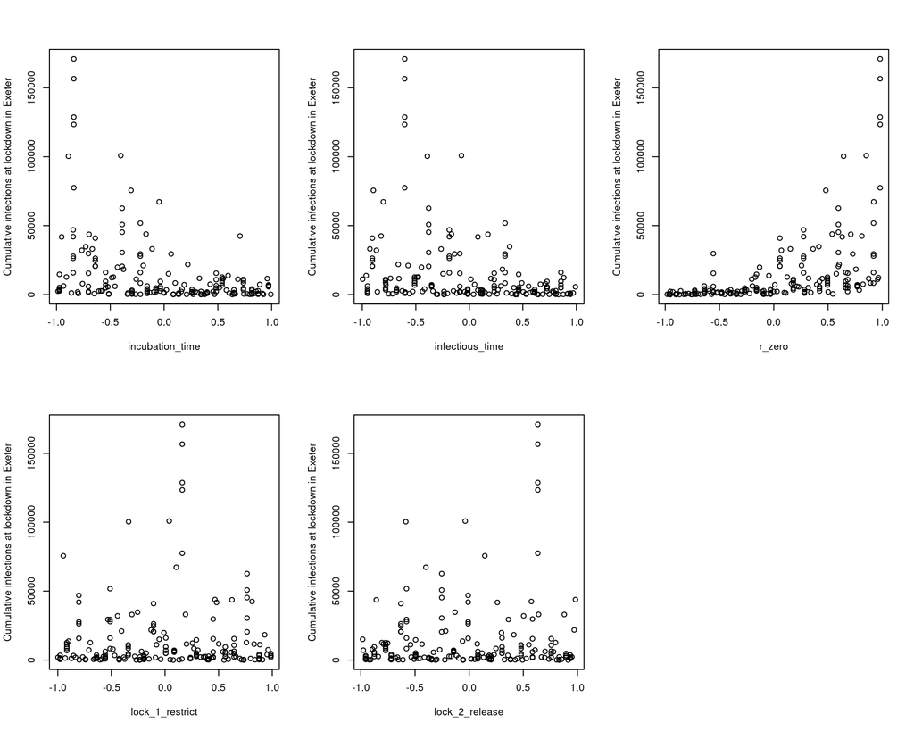

```r
  par(mfrow = c(2,3))
  for(i in 1:5){
     plot(dat[, i], dat$Exeter , xlab = colnames(dat)[i], ylab = 'Cumulative infections at lockdown in Exeter')
  }
```

Have a look at some aggregated data to see if everything is OK. It looks like we have a couple of outliers with more infections than the population of the UK!

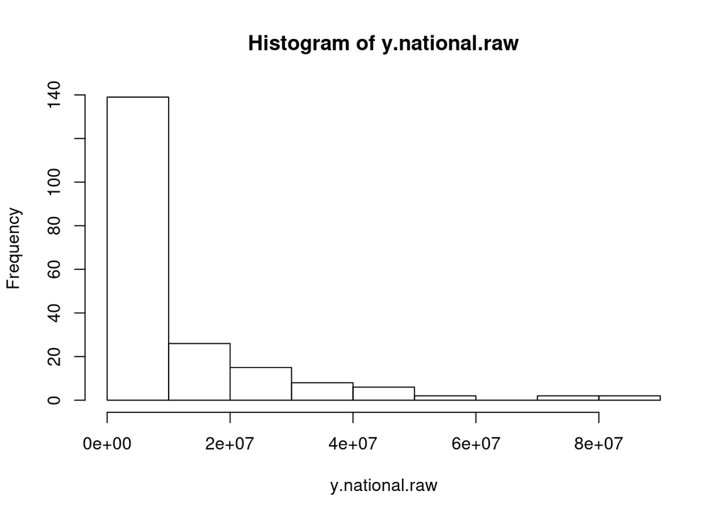

```r
Y.raw <- dat[, 6:ncol(dat)]
y.national.raw <- apply(Y.raw, 1,sum)
hist(y.national.raw)
```

```r
high.ix <- which(y.national.raw > 7e+7)

# Looks like they're all from one run: 46, 47, 48, 49, 50
dat[high.ix ,1:5]
```

```
##    incubation_time infectious_time    r_zero lock_1_restrict
## 46      -0.8391755      -0.6039355 0.9800747       0.1609147
## 47      -0.8391755      -0.6039355 0.9800747       0.1609147
## 48      -0.8391755      -0.6039355 0.9800747       0.1609147
## 50      -0.8391755      -0.6039355 0.9800747       0.1609147
##    lock_2_release
## 46      0.6335409
## 47      0.6335409
## 48      0.6335409
## 50      0.6335409
```

```r
# let's remove all the runs with those input parameters, to be safe.
rm.ix <- 46:50
```

We can see where the outliers are in the design (red points)

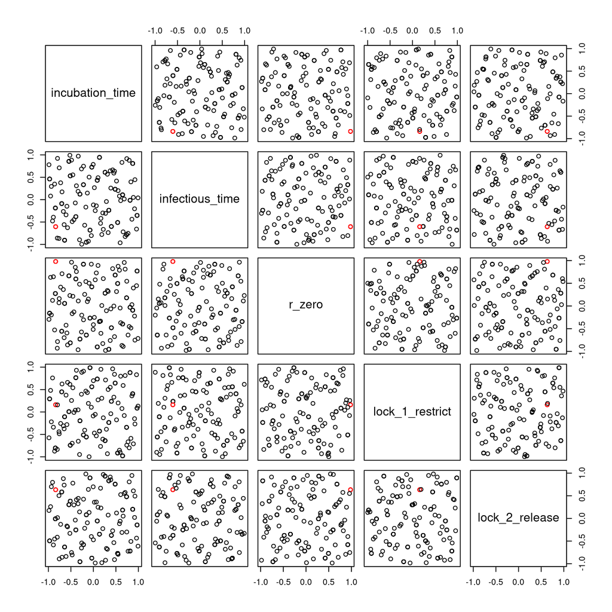

```r
colvec <- rep('black', nrow(dat))
colvec[rm.ix] <- 'red'
pairs(dat[, 1:5], col = colvec)
```

```r
# Remove the design points where the data is obviously in error. We've removed the whole block of the design point where more people are infected than the entire UK population.
# Now, the first 120 rows will be 24 design points with 5 repeats each.
dat.clean <- dat[-rm.ix, ]
```

I’m worried that having repeat runs might break a DiceKriging Emulator, so I’ll pre-process the design and output. This might be only taking one each of the first 125 rows (there are 25 repeated points), or maybe averaging those responses.

```r
dix <- c(seq(from = 1, to = 120, by = 5), 121:195)

X <- dat.clean[dix, 1:5]
X.norm <- normalize(X) # necessary to make e.g. sensitivity analysis code work
X.unnorm <- unnormalize(X.norm, un.mins = apply(uq3a[-rm.ix, 1:5],2,FUN = min), un.maxes = apply(uq3a[-rm.ix,1:5],2, FUN =  max))
Y <- dat.clean[dix, 6:ncol(dat)]
```

## An emulator of national-level cumulative infections

Find the national level cumulative infections.

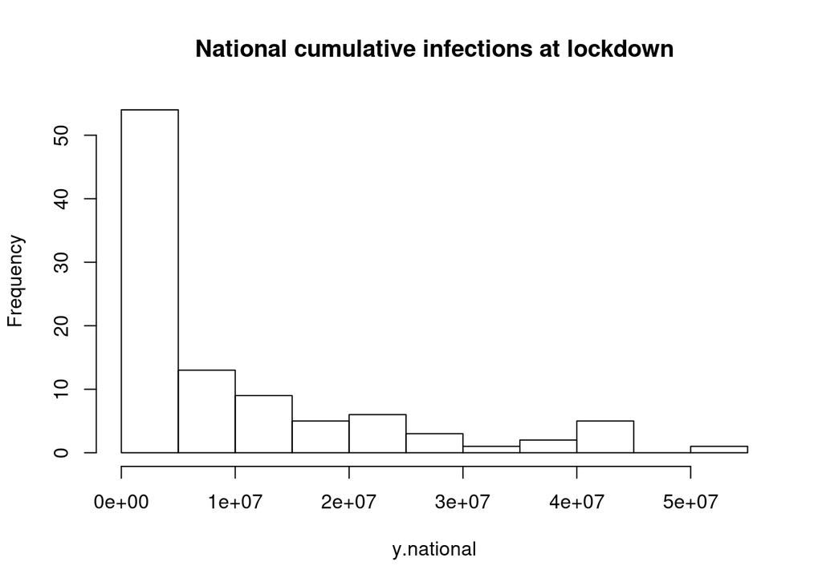

```r
y.national <- apply(Y,1,sum)

hist(y.national, main = 'National cumulative infections at lockdown')
```

Cumulative infections vary marginally with each parameter.

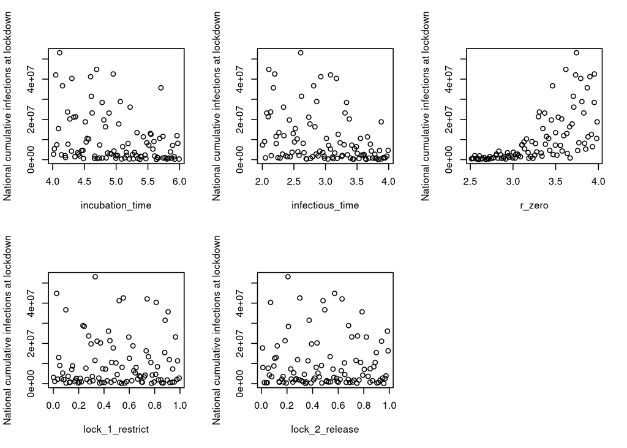

```r
par(mfrow = c(2,3))
  for(i in 1:5){
    plot(X.unnorm[, i],y.national, xlab = colnames(X)[i], ylab = 'National cumulative infections at lockdown')
  }
```

# Look at estimates of variance across parameter space

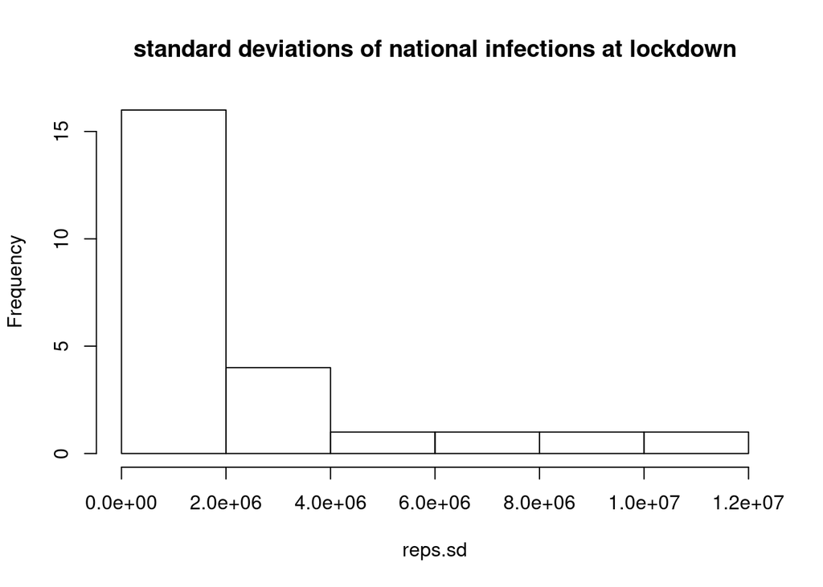

```r
y.all <- apply(dat.clean[,6:ncol(dat.clean)], 1, sum)

y.reps <- y.all[1:120]
reps.list <- split(y.reps, ceiling(seq_along(y.reps)/5))

reps.var <- sapply(reps.list, var)
reps.sd <- sqrt(reps.var)

mean.reps.var <- mean(reps.var)

hist(reps.sd, main = "standard deviations of national infections at lockdown")
```

Fit the emulator, including a homogeneous nugget of the mean variance from the 5 repeats of each of the first 24 design points.

```r
fit.national <- km(~., design = X.norm, response = y.national, nugget = mean.reps.var)
```

```
##
## optimisation start
## ------------------
## * estimation method   : MLE
## * optimisation method : BFGS
## * analytical gradient : used
## * trend model : ~incubation_time + infectious_time + r_zero + lock_1_restrict +
##     lock_2_release
## * covariance model :
##   - type :  matern5_2
##   - nugget : 1.288347e+13
##   - parameters lower bounds :  1e-10 1e-10 1e-10 1e-10 1e-10
##   - parameters upper bounds :  2 2 2 2 2
##   - variance bounds :  4.014027e+12 4.276305e+14
##   - best initial criterion value(s) :  -1672.939
##
## N = 6, M = 5 machine precision = 2.22045e-16
## At X0, 0 variables are exactly at the bounds
## At iterate     0  f=       1672.9  |proj g|=       1.5456
## At iterate     1  f =       1668.3  |proj g|=        1.0885
## At iterate     2  f =       1665.9  |proj g|=        1.6963
## At iterate     3  f =       1664.6  |proj g|=        1.6234
## At iterate     4  f =       1664.2  |proj g|=        1.4052
## At iterate     5  f =         1664  |proj g|=        1.2564
## At iterate     6  f =       1663.6  |proj g|=        1.5183
## At iterate     7  f =       1662.9  |proj g|=       0.65261
## At iterate     8  f =       1662.7  |proj g|=        1.5174
## At iterate     9  f =       1662.7  |proj g|=        1.1987
## At iterate    10  f =       1662.6  |proj g|=        1.1019
## At iterate    11  f =       1662.6  |proj g|=       0.49843
## At iterate    12  f =       1662.6  |proj g|=       0.18676
## At iterate    13  f =       1662.6  |proj g|=     0.0057251
## At iterate    14  f =       1662.6  |proj g|=    0.00024736
##
## iterations 14
## function evaluations 16
## segments explored during Cauchy searches 19
## BFGS updates skipped 0
## active bounds at final generalized Cauchy point 2
## norm of the final projected gradient 0.000247356
## final function value 1662.6
##
## F = 1662.6
```

Quickly check the emulator using leave-one-out cross validation

```r
loo = leaveOneOut.km(fit.national, type = 'UK', trend.reestim = TRUE)
```

The emulator does pretty well.

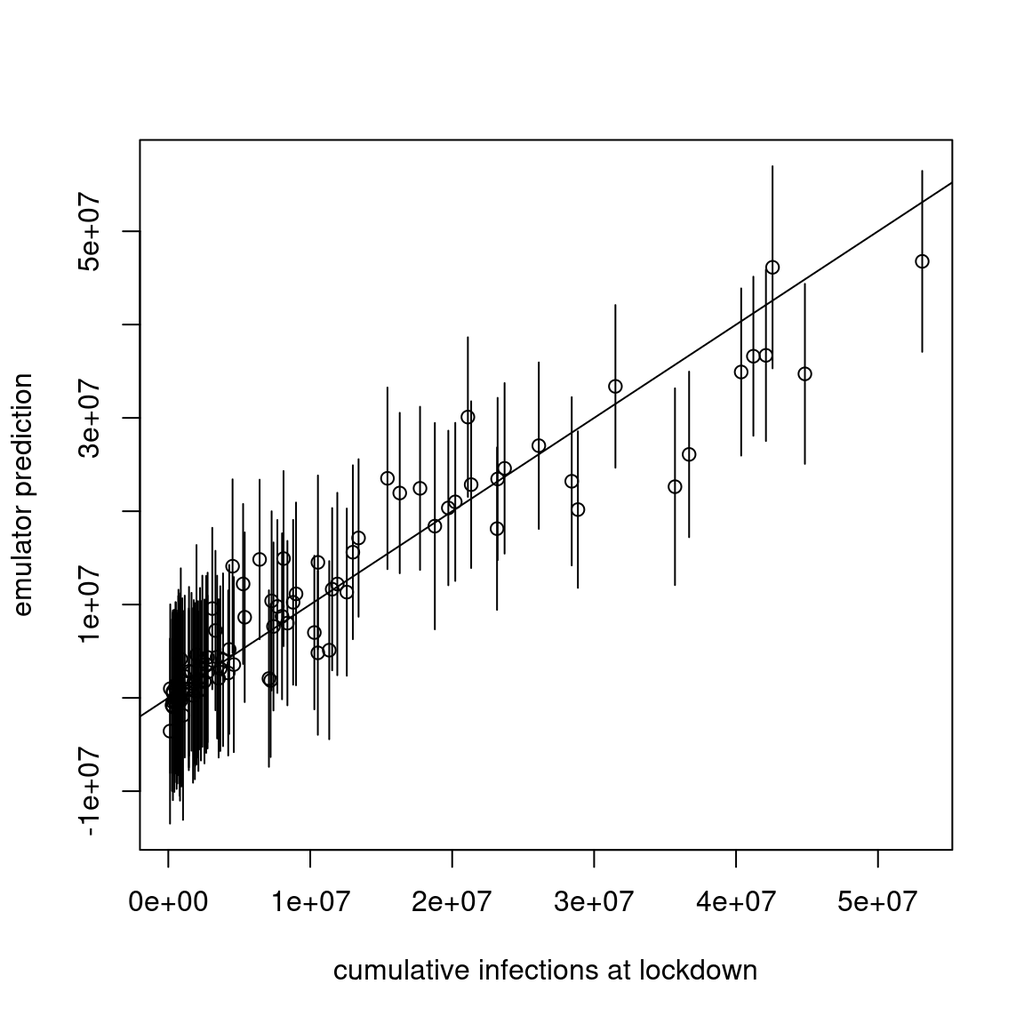

```r
ylim = range(loo$mean - (2*loo$sd),loo$mean + (2*loo$sd) )
plot(y.national, loo$mean, xlab = 'cumulative infections at lockdown', ylab = 'emulator prediction', ylim = ylim)
segments(x0 = y.national, y0 = loo$mean - (2*loo$sd), x1 = y.national, y1 = loo$mean + (2*loo$sd))
abline(0,1)
```

```r
loo.mae = mean(abs(loo$mean - y.national))
```

## Run a FAST99 sensitivity analysis

```r
# Generate a design for the FAST99 analysis
X.fast <- fast99(model = NULL, factors = colnames(X.norm), n = 3000,
                 q = "qunif", q.arg = list(min = 0, max = 1))


# Predict the response at the FAST99 design points using the emulator
pred.fast = predict(fit.national, newdata = X.fast$X, type = 'UK')

# Calculate the sensitivity indices
fast.tell <- tell(X.fast, pred.fast$mean)

bp.convert <- function(fastmodel){
  # get the FAST summary into an easier format for barplot
  fast.summ <- print(fastmodel)
  fast.diff <- fast.summ[ ,2] - fast.summ[ ,1]
  fast.bp <- t(cbind(fast.summ[ ,1], fast.diff))
  fast.bp
}

par(las = 2, mar = c(9,5,3,2))
barplot(bp.convert(fast.tell), col = c('skyblue', 'grey'), ylab = 'relative sensitivity', main = 'FAST99 Sensitivity')
```

```
##
## Call:
## fast99(model = NULL, factors = colnames(X.norm), n = 3000, q = "qunif",     q.arg = list(min = 0, max = 1))
##
## Model runs: 15000
##
## Estimations of the indices:
##                  first order total order
## incubation_time 0.1350426183 0.243232603
## infectious_time 0.1450104999 0.266147136
## r_zero          0.4995677200 0.697277173
## lock_1_restrict 0.0004228261 0.003132580
## lock_2_release  0.0002238129 0.003156239
```

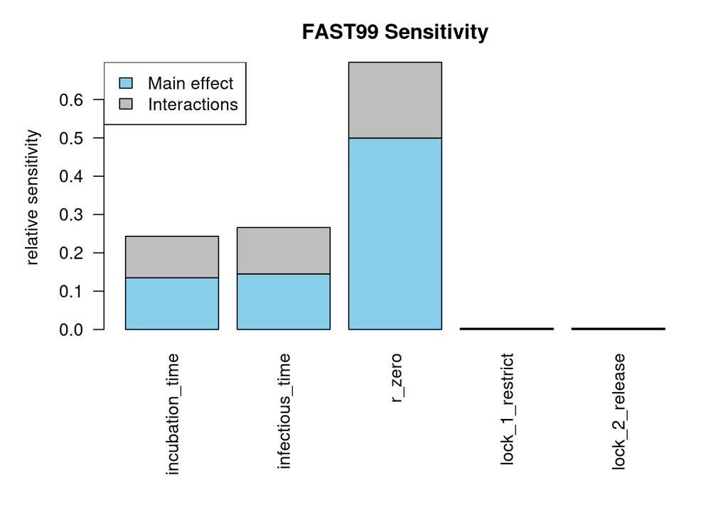

```r
legend('topleft',legend = c('Main effect', 'Interactions'), fill = c('skyblue', 'grey') )
```

## Run a one-at-a-time sensitivity analysis

Parameters are swept across their range one at a time, with the remaining parameters held at central values.

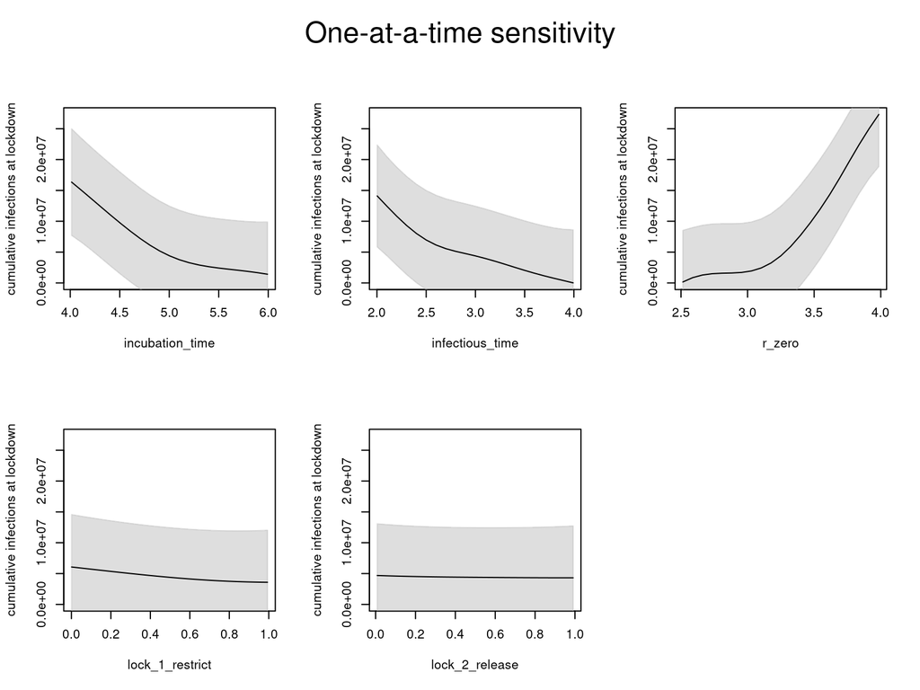

```r
n.oat <- 21
X.oat <- oaat.design(X.norm, n = n.oat, hold = rep(0.5,5))
X.oat.un <- unnormalize(X.oat, un.mins = apply(uq3a[,1:5],2,FUN = min), un.maxes = apply(uq3a[,1:5],2, FUN =  max))

parnames <- colnames(X)
colnames(X.oat) <- parnames
pred.oat <- predict(fit.national, newdata = X.oat, type = 'UK')

col.transp <- adjustcolor('grey', alpha = 0.5)
par(mfrow = c(2,3), oma = c(0.1,0.1,3,0.1))

  for(i in 1:5){

  ix <- seq(from = ((i*n.oat) - (n.oat-1)), to =  (i*n.oat), by = 1)

  plot(X.oat.un[ix,i], pred.oat$mean[ix]
       , ylim = range(pred.oat$mean),
       xlab = parnames[i], ylab = 'cumulative infections at lockdown',
       type= 'n')

     polygon(x = c(X.oat.un[ix, i], rev(X.oat.un[ix, i])),
            y = c(pred.oat$mean[ix] - (2*pred.oat$sd[ix]), rev(pred.oat$mean[ix] + (2*pred.oat$sd[ix]))),
            col = col.transp, border = col.transp)

  lines(X.oat.un[ix,i], pred.oat$mean[ix], xlim = c(0,1), lty = 'solid')

  }

mtext('One-at-a-time sensitivity', side = 3, outer = TRUE, cex = 1.5)
```

## A quick comparison with data (or at least, with another model)

What input space is consistent with the estimated cumulative infections from Jit et al.?

```r
#Have a very quick look at how much input space is removed by a comparison with data
# Useful data for comparisons later
# https://www.ons.gov.uk/peoplepopulationandcommunity/healthandsocialcare/conditionsanddiseases/bulletins/coronaviruscovid19infectionsurveypilot/england14may2020

# Jit et al estimate the number of infections at lockdown
# https://www.eurosurveillance.org/content/10.2807/1560-7917.ES.2020.25.18.2000632
#
# We estimated that each COVID-19 case admitted to CC reported in FF100 and CHESS corresponded to a median of 124 (95%
# credible interval (CrI): 81–11,500) and 120 (95% CrI: 76–46,600) infected individuals in the population, respectively, based on Chinese and US severity data [5,6].

#The Figure shows the number of incident cases estimated on each day between 16 February and 23 March. On 23 March, 114,000 (95% CrI: 78,000–173,000) new cases and 258 (95% CrI: 220–319) CC reports are estimated to have occurred, with 527,000 (95% CrI: 362,000–797,000) cumulative cases since 16 February. The best fitting exponential growth rates were consistent with an epidemic doubling time of 2.8 days (95% CrI: 2.6–3.0). Assuming an exponentially distributed serial interval of 4 days [8] gave an (approximate) reproduction number of 2.0 (95% CrI: 1.9–2.1). If we assume a longer serial interval of 6 days that may be expected at the start of an epidemic, the reproduction number could be 2.5 (95% CrI: 2.4–2.6).


# Samples from a uniform distribution across all of input space
nsamp.unif <- 500000
X.unif = samp.unif(nsamp.unif, mins = rep(0, ncol(X)), maxes = rep(1, ncol(X)))
colnames(X.unif) <- colnames(X)

pred.unif <- predict(fit.national, newdata = X.unif, type = 'UK')

# whart part of parameter space is implied by Jit et al. (within the 95% CI)?
ix.kept <- which(pred.unif$mean > 362000 & pred.unif$mean < 797000)

# Un-normalize and plot
X.unif.kept <- X.unif[ix.kept, ]
colnames(X.unif.kept) <- colnames(X)

X.unif.kept.unnorm <- unnormalize(X.unif.kept, un.mins = apply(uq3a[-rm.ix, 1:5],2,FUN = min), un.maxes = apply(uq3a[-rm.ix,1:5],2, FUN =  max))
```

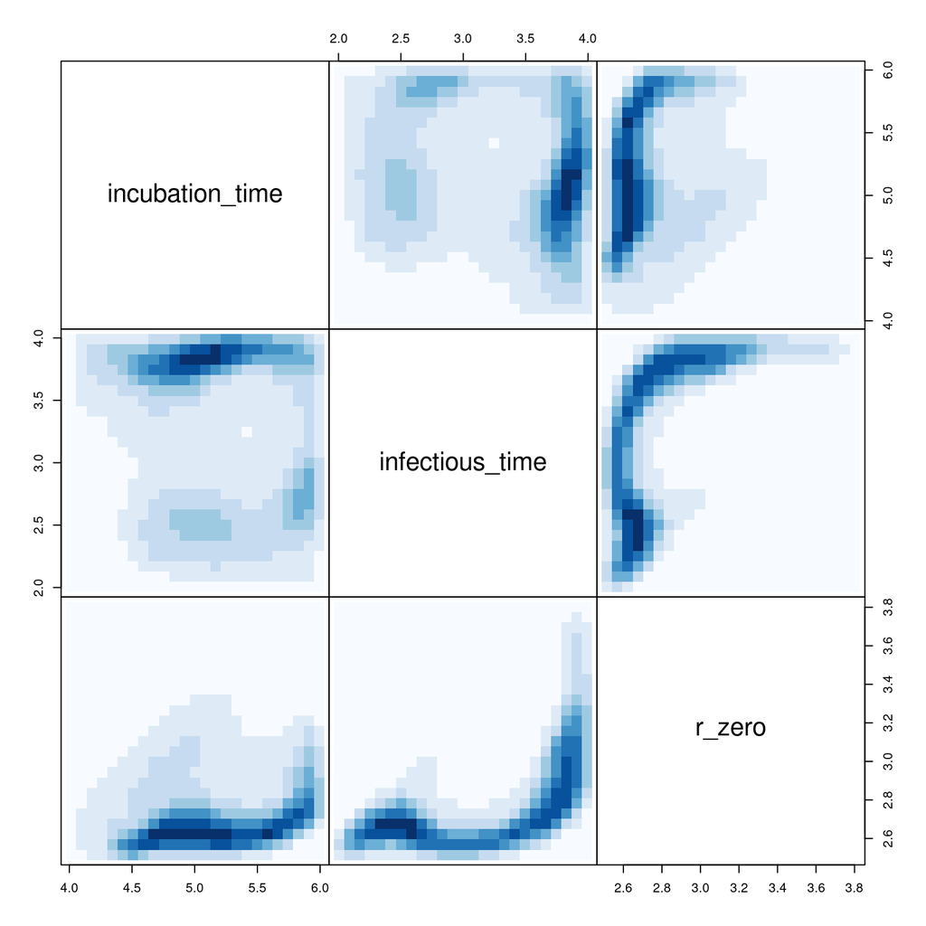

```r
library(RColorBrewer)
blues = brewer.pal(9, 'Blues')


pairs(X.unif.kept.unnorm[, 1:3],
      gap = 0,
      panel = dfunc.up,
      dfunc.col = blues
      )
```

It looks like R0 is low using this data, but that this isn’t surprising - Jit et al say the data is consistent with R0 around 2.5.